# Demonstration of Data Preprocess and Simple Association Test Using Toy Examples

This notebook demonstrates a standard approach to conduct the genome wide association study (GWAS) using toy example datasets. The procedures consist of four steps:

1. Quality Control
2. Imputation
3. Population Stratification Correction
4. Simple Association Test

The data used for this example is a toy genotype data containing 5 random SNPs and a random phenotype data with covariates.

We use both bash and R codes in this notebook. The type of programming language is labeled at the top of each code cell.

**Special notes for Windows users: Windows has two command-line shells, Command shell and Windows Powershell. Command shell is specific to Windows system and can be run from RStudio Terminal or in "Command Prompt" App, but the lanugage it uses is NOT the same as Bash! Powershell App is the only place to run Bash commands in Windows. Therefore if you are Windows users and use RStudio for this course, you can't run bash codes such as "head" or "awk" from RStudio Terminal, you can **ONLY** run PLINK program codes. If you would like to try Bash codes, please open "Windows Powershell" app and follow the same steps to set the paths. Still, Powershell App won't run PLINK codes, so you'll have to switch between Pwershell and RStudio Terminal.**

# Environment Setting

Before we can run any analysis, we need to set the working directory path to the downloaded "bigcare-main" folder for both Terminal and Console in RStudio. Below are the codes to setup paths at both places. These paths have to be setup correctly at first, otherwise we can't locate the correct input files.

```python
# change the paths to where you saved "bigcare-main"
## run in Terminal
mydir="/path/to/bigcare-main"
cd $mydir

# R codes- run in R Console
setwd("/path/to/bigcare-main")
```

```
User guides for each biocontainer module can be found in
https://www.rcac.purdue.edu/knowledge/biocontainers
User guides for each biocontainer module can be found in
https://www.rcac.purdue.edu/knowledge/biocontainers
```

# GWAS Tools

We will use two main program tools in this notebook, **PLINK** and **IMPUTE2**.

**PLINK** is used for quality control and perform association test for large scale genotype data. You can download PLINK program using [this link](https://zzz.bwh.harvard.edu/plink/download.shtml). Download the .zip file or find the .zip files suitable for your laptop system in "bigcare-main/Tools/PLINK" and unzip it to call the `plink` program in the folder.

**IMPUTE2** is used for genotype imputation and haplotype phasing. You can download its program using [this link](https://mathgen.stats.ox.ac.uk/impute/impute_v2.html#download). IMPUTE2 program is only available to run in Linux or macOS system. You can find the zipped installation file in "bigcare-main/Tools/IMPUTE2". If you want to perform imputation for your own data, you also need to download the required reference genome from the above link. But in this notebook will only use the example genome.

**Important: If you want to run these two programs on your laptop, please make sure you have unzipped the installation packages in "./bigcare-main/Tools" that is suitable for your laptop systerm. We will directly call PLINK and IMPUTE2 programs using relative path.**

For example, my computer is macOS system so I can run both PLINK and IMPUTE2. After I downloaded "bigcare-main" folder, I open `./Tools/PLINK` and unzip the plink package for macOS: "plink_mac_20230116.zip". A folder "plink_mac_20230116" will be created which contains a program file called "plink". Then, I can call PLINK program by specifying the absolute path of this "plink" program: `/path/to/bigcare-main/Tools/PLINK/plink_mac_20230116/plink`. Similar for Windows system, you need to unzip the package "plink_win64_20230116.zip" with right click->"Extract All...". Then you can call PLINK with `/path/to/bigcare-main/Tools/PLINK/plink_win64_20230116/plink.exe`.

Similar for IMPUTE2, I unzip "impute_v2.3.2_MacOSX_Intel.tgz" for macOS under "./bigcare-main/Tools/IMPUTE2/". And I can call IMPUTE2 program with `/path/to/bigcare-main/Tools/IMPUTE2/impute_v2.3.2_MacOSX_Intel/impute2`. Note that Windows system won't be able to run IMPUTE2.

You should modify the above `/path/to/bigcare` to where your "bigcare-main" folder is.

**However, macOS users need to go through additional steps to authorize PLINK and IMPUTE2 programs before you can call them! See below.**

When you try to call PLINK or IMPUTE2 with the above commands, you might get a pop-up window with the following message `“plink” cannot be opened because the developer cannot be verified.`. Select "Cancel" and we will authorize PLINK first. Please go to macOS "System Settings"->"Privacy & Security", and scroll down until you see a message `"plink" was blocked from use because it is not from an identified developer.`. Click "Allow Anyway" and you will be prompt to enter your Mac username and password. Click "Unlock" and then"Allow Anyway" again, and the previous message will disappear. Then try to run the same codes again in RStudio Terminal. You will get another pop-up window saying `macOS cannot verify the developer of “plink”. Are you sure you want to open it?`, select "Open" then you can see PLINK or IMPUTE2 commands options show up in Terminal.

# Quality Control

**PLINK** will generate a number of standard summary statistics that are useful for quality control (e.g. missing genotype rate, minor allele frequency, Hardy-Weinberg equilibrium test and non-Mendelian transmission rate). These can also be used as thresholds for subsequent analyses. For more detailed information about plink, please refer its website http://zzz.bwh.harvard.edu/plink/.

The following is a list of some common options that can be used to filter out individuals or SNPs on the basis of the summary statistic measures:

| Feature inclusion criteria | As summary statistic | As inclusion criteria |
| --- | --- | --- |
| Missingness per individual | `--missing` | `--mind N` |
| Missingness per marker | `--missing` | `--geno N` |
| Allele frequency | `--freq` | `--maf N` |
| Hardy-Weinberg equilibrium | `--hardy` | `--hwe N` |

## An Example of Summary Statistics

### Input files

Input files: in folder `./Data/QC`-- We will use a random selected 5 SNPs as an example data:

- 5SNPs.ped
- 5SNPs.map

The PED file is a white-space delimited file: the first six columns are mandatory:

```
 Family ID
 Individual ID
 Paternal ID
 Maternal ID
 Sex (1=male; 2=female; other=unknown)
 Phenotype
```

```python
# bash codes- run in Terminal
# Windows user need to run in Powershell App
head ./Data/QC/5SNPs.ped
```

```
User guides for each biocontainer module can be found in
https://www.rcac.purdue.edu/knowledge/biocontainers
```

```
1 206-001 0 0 1 0 A A G G G G G G A A
2 206-003 0 0 1 0 A A G G G G G G A A
3 206-004 0 0 1 0 A A G G G G G G A A
4 206-014 0 0 1 0 A A G G G G G G A A
5 206-015 0 0 1 0 A G A G A G A G A A
6 206-016 0 0 1 0 A G A G A G A G A A
7 206-018 0 0 1 0 A A G G G G G G A A
8 206-019 0 0 1 0 A A A G A G A G A G
9 206-021 0 0 1 0 A A G G G G G G A A
10 206-023 0 0 1 0 A G A G A G A G A A
```

By default, each line of the MAP file describes a single marker and must contain exactly 4 columns:

```
 chromosome (1-22, X, Y or 0 if unplaced)
 rs# or snp identifier
 Genetic distance (morgans)
 Base-pair position (bp units)
```

```python
# bash codes- run in terminal
# Windows user need to run in Powershell App
head ./Data/QC/5SNPs.map
```

```
1 rs3094315 0 752566
1 rs2073813 0 753541
1 rs3131969 0 754182
1 rs3131967 0 754334
1 rs77598327 0 757120
```

Three types of summary statistics that we are going to calculate using `PLINK`:

1. missingness checking
2. allele frequencies
3. hardy-weinberg

All results generated from the following commands are saved in folder `./Data/QC`. You can open the files in this folder to view the data structure.

### Calculating missing rate

The following commands compute the **missingness** for each SNP and each subject. (The output will print all calculation progress generated by `PLINK`.)

1. **--noweb**, suppress the connection to internet for version check.
2. **--file**, specify the input files. Same for the other functions of plink in unit 4.
3. **--missing**, calculate the number of missing and missing rate.
4. **--out**, specify the output file name. Same for the other functions of plink in unit 4.

```python
# both Mac and Windows can run in Terminal
# modify the path to "plink" program

# for macoS users
./Tools/PLINK/plink_mac_20230116/plink \
--noweb --file ./Data/QC/5SNPs --missing --out ./Data/QC/younameit

# for windows users
./Tools/PLINK/plink_win64_20230116/plink.exe \
--noweb --file ./Data/QC/5SNPs --missing --out ./Data/QC/younameit
```

```
PLINK v1.90b6.21 64-bit (19 Oct 2020)          www.cog-genomics.org/plink/1.9/
(C) 2005-2020 Shaun Purcell, Christopher Chang   GNU General Public License v3
Logging to ./Data/QC/younameit.log.
Options in effect:
  --file ./Data/QC/5SNPs
  --missing
  --noweb
  --out ./Data/QC/younameit

Note: --noweb has no effect since no web check is implemented yet.
257520 MB RAM detected; reserving 128760 MB for main workspace.
.ped scan complete (for binary autoconversion).313141414151515151616161717171718181819191919202020212121212…%
Performing single-pass .bed write (5 variants, 344 people).
--file: ./Data/QC/younameit-temporary.bed + ./Data/QC/younameit-temporary.bim +9505152535455565758596061626364656667686970717273747576777879808182838485868788899091929394%
./Data/QC/younameit-temporary.fam written.
5 variants loaded from .bim file.
344 people (281 males, 0 females, 63 ambiguous) loaded from .fam.
Ambiguous sex IDs written to ./Data/QC/younameit.nosex .
Using 1 thread (no multithreaded calculations invoked).
Before main variant filters, 344 founders and 0 nonfounders present.
Calculating allele frequencies... 10111213141516171819202122232425262728293031323334353637383940414243444546474849505152535455565758596061626364656667686970717273747576777879808182838485868788899091929394959697989 done.
Total genotyping rate is 0.976744.
--missing: Sample missing data report written to ./Data/QC/younameit.imiss, and
variant-based missing data report written to ./Data/QC/younameit.lmiss.
```

This option creates two output files in './Data/QC' folder:

1. **["younameit.imiss"](https://github.com/danniliustat/bigcare/blob/main/Data/QC/younameit.imiss)**, missingness by individual.
2. **["younameit.lmiss"](https://github.com/danniliustat/bigcare/blob/main/Data/QC/younameit.lmiss)**, missingness by SNP.

For individuals ".imiss" file, the format is:

```
 FID                Family ID
 IID                Individual ID
 MISS_PHENO         Missing phenotype? (Y/N)
 N_MISS             Number of missing SNPs
 N_GENO             Number of non-obligatory missing genotypes
 F_MISS             Proportion of missing SNPs
```

```python
# bash codes- run in Terminal
# Windows user need to run in Powershell App
head ./Data/QC/younameit.imiss
```

```
 FID       IID MISS_PHENO   N_MISS   N_GENO   F_MISS
   1   206-001          Y        0        5        0
   2   206-003          Y        0        5        0
   3   206-004          Y        0        5        0
   4   206-014          Y        0        5        0
   5   206-015          Y        0        5        0
   6   206-016          Y        0        5        0
   7   206-018          Y        0        5        0
   8   206-019          Y        0        5        0
   9   206-021          Y        0        5        0
```

For SNP "lmiss" file, the format is:

```
 SNP                SNP identifier
 CHR                Chromosome number
 N_MISS             Number of individuals missing this SNP
 N_GENO             Number of non-obligatory missing genotypes
 F_MISS             Proportion of sample missing for this SNP
```

```python
# bash codes- run in terminal
# Windows user need to run in Powershell App
head ./Data/QC/younameit.lmiss
```

```
 CHR         SNP   N_MISS   N_GENO   F_MISS
   1   rs3094315        2      344 0.005814
   1   rs2073813       14      344   0.0407
   1   rs3131969       11      344  0.03198
   1   rs3131967        3      344 0.008721
   1  rs77598327       10      344  0.02907
```

### Calculating allel frequencies

The following command computes the **allele frequencies**. (The output will print all calculation progress generated by `PLINK`.)

1. **--freq**, calculate the allele frequencies.

```python
# both Mac and Windows can run in Terminal
# modify the path to "plink" program

# macOS user
./Tools/PLINK/plink_mac_20230116/plink \
--noweb --file ./Data/QC/5SNPs --freq --out ./Data/QC/younameit

# Windows user
./Tools/PLINK/plink_win64_20230116/plink.exe \
--noweb --file ./Data/QC/5SNPs --freq --out ./Data/QC/younameit
```

```
PLINK v1.90b6.21 64-bit (19 Oct 2020)          www.cog-genomics.org/plink/1.9/
(C) 2005-2020 Shaun Purcell, Christopher Chang   GNU General Public License v3
Logging to ./Data/QC/younameit.log.
Options in effect:
  --file ./Data/QC/5SNPs
  --freq
  --noweb
  --out ./Data/QC/younameit

Note: --noweb has no effect since no web check is implemented yet.
257520 MB RAM detected; reserving 128760 MB for main workspace.
.ped scan complete (for binary autoconversion).313141414151515151616161717171718181819191919202020212121212…%
Performing single-pass .bed write (5 variants, 344 people).
--file: ./Data/QC/younameit-temporary.bed + ./Data/QC/younameit-temporary.bim +9505152535455565758596061626364656667686970717273747576777879808182838485868788899091929394%
./Data/QC/younameit-temporary.fam written.
5 variants loaded from .bim file.
344 people (281 males, 0 females, 63 ambiguous) loaded from .fam.
Ambiguous sex IDs written to ./Data/QC/younameit.nosex .
Using 1 thread (no multithreaded calculations invoked).
Before main variant filters, 344 founders and 0 nonfounders present.
Calculating allele frequencies... 10111213141516171819202122232425262728293031323334353637383940414243444546474849505152535455565758596061626364656667686970717273747576777879808182838485868788899091929394959697989 done.
Total genotyping rate is 0.976744.
--freq: Allele frequencies (founders only) written to ./Data/QC/younameit.frq .
```

This command will create a output file **["younameit.frq"](https://github.com/danniliustat/bigcare/blob/main/Data/QC/younameit.frq)** with six columns:

```
 CHR       Chromosome

 SNP       SNP identifier

 A1        Allele 1 code (minor allele)

 A2        Allele 2 code (major allele)

 MAF       Minor allele frequency

 NCHROBS   Non-missing allele count
```

```python
# bash codes- run in terminal
# Windows user need to run in Powershell App
head ./Data/QC/younameit.frq
```

```
 CHR         SNP   A1   A2          MAF  NCHROBS
   1   rs3094315    G    A      0.07749      684
   1   rs2073813    A    G       0.2242      660
   1   rs3131969    A    G       0.2387      666
   1   rs3131967    A    G       0.2082      682
   1  rs77598327    G    A       0.1228      668
```

### Hardy-Weinberg Equilibrium

The following command computes the **Hardy-Weiberg test**. (The output will print all calculation progress generated by `PLINK`.)

1. **--hardy**, perform hardy-weinberg test.

```python
# both Mac and Windows can run in Terminal
# modify the path to "plink" program

# macOS user
./Tools/PLINK/plink_mac_20230116/plink \
--noweb --file ./Data/QC/5SNPs --hardy --out ./Data/QC/younameit

# Windows user
./Tools/PLINK/plink_win64_20230116/plink.exe \
--noweb --file ./Data/QC/5SNPs --hardy --out ./Data/QC/younameit
```

```
PLINK v1.90b6.21 64-bit (19 Oct 2020)          www.cog-genomics.org/plink/1.9/
(C) 2005-2020 Shaun Purcell, Christopher Chang   GNU General Public License v3
Logging to ./Data/QC/younameit.log.
Options in effect:
  --file ./Data/QC/5SNPs
  --hardy
  --noweb
  --out ./Data/QC/younameit

Note: --noweb has no effect since no web check is implemented yet.
257520 MB RAM detected; reserving 128760 MB for main workspace.
.ped scan complete (for binary autoconversion).313141414151515151616161717171718181819191919202020212121212…%
Performing single-pass .bed write (5 variants, 344 people).
--file: ./Data/QC/younameit-temporary.bed + ./Data/QC/younameit-temporary.bim +9505152535455565758596061626364656667686970717273747576777879808182838485868788899091929394%
./Data/QC/younameit-temporary.fam written.
5 variants loaded from .bim file.
344 people (281 males, 0 females, 63 ambiguous) loaded from .fam.
Ambiguous sex IDs written to ./Data/QC/younameit.nosex .
Using 1 thread (no multithreaded calculations invoked).
Before main variant filters, 344 founders and 0 nonfounders present.
Calculating allele frequencies... 10111213141516171819202122232425262728293031323334353637383940414243444546474849505152535455565758596061626364656667686970717273747576777879808182838485868788899091929394959697989 done.
Total genotyping rate is 0.976744.
--hardy: Writing Hardy-Weinberg report (founders only) to
./Data/QC/younameit.hwe ... 101112131415161718192021222324252627282930313233343536373839404142434445464748495051525354555657585960616263646566676869707172737475767778798081828384858687888990919293949596979899done.
```

This command will create an output file **["younameit.hwe"](https://github.com/danniliustat/bigcare/blob/main/Data/QC/younameit.hwe)** with the following columns:

```
 SNP             SNP identifier

 TEST            Code indicating whether the sample is a case or control

 A1              Minor allele code

 A2              Major allele code

 GENO            Genotype counts: 11/12/22

 O(HET)          Observed heterozygosity

 E(HET)          Expected heterozygosity

 P               P-value for Hardy-Weinberg test
```

```python
# bash codes- run in terminal
# Windows user need to run in Powershell App
head ./Data/QC/younameit.hwe
```

```
 CHR         SNP     TEST   A1   A2                 GENO   O(HET)   E(HET)            P
   1   rs3094315  ALL(NP)    G    A             3/47/292   0.1374    0.143       0.4398
   1   rs2073813  ALL(NP)    A    G           18/112/200   0.3394   0.3479       0.6366
   1   rs3131969  ALL(NP)    A    G           24/111/198   0.3333   0.3635       0.1323
   1   rs3131967  ALL(NP)    A    G           12/118/211    0.346   0.3297       0.4149
   1  rs77598327  ALL(NP)    G    A             2/78/254   0.2335   0.2154       0.1984
```

## An Example of Inclusion Thresholds for QC

Input files: in folder `./Data/QC`

- 5SNPs.ped
- 5SNPs.map

The following command performs **multiple quality controls**. (The output will print all calculation progress generated by `PLINK`.)

1. **--mind** 0.1, exclude the individuals with missing rate larger than 0.1. You can change 0.1 to other desired values.
2. **--geno** 0.1, exclude the SNPs with missing rate larger than 0.1. You can change 0.1 to other desiered values.
3. **--maf** 0.05, exclude the SNPs with minor allele frequency (MAF) smaller than 0.05. You can change 0.05 to other desiered values.
4. **--hwe** 0.001, exclude the SNPs with P-values of Hardy-Weinberg test smaller than 0.001. You can change it to otehr desired values.
5. **--recode**, generate a new dataset.

```python
# both Mac and Windows can run in Terminal
# modify the path to "plink" program

# macOS user
./Tools/PLINK/plink_mac_20230116/plink \
--noweb --file ./Data/QC/5SNPs \
--mind 0.1 --geno 0.1 --maf 0.05 --hwe 0.001 --recode --out ./Data/QC/younameit

# Windows user
./Tools/PLINK/plink_win64_20230116/plink.exe \
--noweb --file ./Data/QC/5SNPs \
--mind 0.1 --geno 0.1 --maf 0.05 --hwe 0.001 --recode --out ./Data/QC/younameit
```

```
PLINK v1.90b6.21 64-bit (19 Oct 2020)          www.cog-genomics.org/plink/1.9/
(C) 2005-2020 Shaun Purcell, Christopher Chang   GNU General Public License v3
Logging to ./Data/QC/younameit.log.
Options in effect:
  --file ./Data/QC/5SNPs
  --geno 0.1
  --hwe 0.001
  --maf 0.05
  --mind 0.1
  --noweb
  --out ./Data/QC/younameit
  --recode

Note: --noweb has no effect since no web check is implemented yet.
257520 MB RAM detected; reserving 128760 MB for main workspace.
.ped scan complete (for binary autoconversion).313141414151515151616161717171718181819191919202020212121212…%
Performing single-pass .bed write (5 variants, 344 people).
--file: ./Data/QC/younameit-temporary.bed + ./Data/QC/younameit-temporary.bim +9505152535455565758596061626364656667686970717273747576777879808182838485868788899091929394%
./Data/QC/younameit-temporary.fam written.
5 variants loaded from .bim file.
344 people (281 males, 0 females, 63 ambiguous) loaded from .fam.
Ambiguous sex IDs written to ./Data/QC/younameit.nosex .
32 people removed due to missing genotype data (--mind).
IDs written to ./Data/QC/younameit.irem .
Using 1 thread (no multithreaded calculations invoked).
Before main variant filters, 312 founders and 0 nonfounders present.
Calculating allele frequencies... 10111213141516171819202122232425262728293031323334353637383940414243444546474849505152535455565758596061626364656667686970717273747576777879808182838485868788899091929394959697989 done.
0 variants removed due to missing genotype data (--geno).
--hwe: 0 variants removed due to Hardy-Weinberg exact test.
0 variants removed due to minor allele threshold(s)
(--maf/--max-maf/--mac/--max-mac).
5 variants and 312 people pass filters and QC.
Note: No phenotypes present.
--recode ped to ./Data/QC/younameit.ped + ./Data/QC/younameit.map ... 101112131415161718192021222324252627282930313233343536373839404142434445464748495051525354555657585960616263646566676869707172737475767778798081828384858687888990919293949596979899done.
```

The output files will be **["younameit.map"](https://github.com/danniliustat/bigcare/blob/main/Data/QC/younameit.map)** and **["younameit.ped"](https://github.com/danniliustat/bigcare/blob/main/Data/QC/younameit.ped)** which have been quality controlled by the criteria you specified.

## Remove Closely Related Individuals

Input files: in folder `./Data/QC`

- 5SNPs.ped
- 5SNPs.map

The following command will calculate **indentical by descent (IBS) distances** between all individuals.

1. **--genome**, calculate IBS

```python
# both Mac and Windows can run in Terminal
# modify the path to "plink" program

# macOS user
./Tools/PLINK/plink_mac_20230116/plink \
--noweb --file ./Data/QC/5SNPs --genome --out ./Data/QC/younameit

# Windows user
./Tools/PLINK/plink_win64_20230116/plink.exe \
--noweb --file ./Data/QC/5SNPs --genome --out ./Data/QC/younameit
```

```
PLINK v1.90b6.21 64-bit (19 Oct 2020)          www.cog-genomics.org/plink/1.9/
(C) 2005-2020 Shaun Purcell, Christopher Chang   GNU General Public License v3
Logging to ./Data/QC/younameit.log.
Options in effect:
  --file ./Data/QC/5SNPs
  --genome
  --noweb
  --out ./Data/QC/younameit

Note: --noweb has no effect since no web check is implemented yet.
257520 MB RAM detected; reserving 128760 MB for main workspace.
.ped scan complete (for binary autoconversion).313141414151515151616161717171718181819191919202020212121212…%
Performing single-pass .bed write (5 variants, 344 people).
--file: ./Data/QC/younameit-temporary.bed + ./Data/QC/younameit-temporary.bim +9505152535455565758596061626364656667686970717273747576777879808182838485868788899091929394%
./Data/QC/younameit-temporary.fam written.
5 variants loaded from .bim file.
344 people (281 males, 0 females, 63 ambiguous) loaded from .fam.
Ambiguous sex IDs written to ./Data/QC/younameit.nosex .
Using up to 127 threads (change this with --threads).
Before main variant filters, 344 founders and 0 nonfounders present.
Calculating allele frequencies... 10111213141516171819202122232425262728293031323334353637383940414243444546474849505152535455565758596061626364656667686970717273747576777879808182838485868788899091929394959697989 done.
Total genotyping rate is 0.976744.
5 variants and 344 people pass filters and QC.
Note: No phenotypes present.
IBD calculations complete.
Finished writing ./Data/QC/younameit.genome .
```

This will create the file **["younameit.genome"](https://github.com/danniliustat/bigcare/blob/main/Data/QC/younameit.genome)** which has the following fields:

```
 FID1      Family ID for first individual

 IID1      Individual ID for first individual

 FID2      Family ID for second individual

 IID2      Individual ID for second individual

 RT        Relationship type given PED file

 EZ        Expected IBD sharing given PED file

 Z0        P(IBD=0)

 Z1        P(IBD=1)

 Z2        P(IBD=2)

 PI_HAT    P(IBD=2)+0.5*P(IBD=1) ( proportion IBD )

 PHE       Pairwise phenotypic code (1,0,-1 = AA, AU and UU pairs)

 DST       IBS distance (IBS2 + 0.5*IBS1) / ( N SNP pairs )

 PPC       IBS binomial test

 RATIO     Of HETHET : IBS 0 SNPs (expected value is 2)
```

Scan the output file **"younameit.genome"** for any individuals with high **PI_HAT** values (e.g. greater than 0.05).

Optionally, remove one member of the pair if close relatives are identified.

```python
# bash codes- run in terminal
# Windows user need to run in Powershell App
head ./Data/QC/younameit.genome
```

```
 FID1     IID1 FID2     IID2 RT    EZ      Z0      Z1      Z2  PI_HAT PHE       DST     PPC   RATIO
   1  206-001   2  206-003 UN    NA  0.0000  0.0000  1.0000  1.0000  -1  1.000000      NA      NA
   1  206-001   3  206-004 UN    NA  0.0000  0.0000  1.0000  1.0000  -1  1.000000      NA      NA
   1  206-001   4  206-014 UN    NA  0.0000  0.0000  1.0000  1.0000  -1  1.000000      NA      NA
   1  206-001   5  206-015 UN    NA  0.0000  1.0000  0.0000  0.5000  -1  0.600000      NA      NA
   1  206-001   6  206-016 UN    NA  0.0000  1.0000  0.0000  0.5000  -1  0.600000      NA      NA
   1  206-001   7  206-018 UN    NA  0.0000  0.0000  1.0000  1.0000  -1  1.000000      NA      NA
   1  206-001   8  206-019 UN    NA  0.0000  1.0000  0.0000  0.5000  -1  0.600000      NA      NA
   1  206-001   9  206-021 UN    NA  0.0000  0.0000  1.0000  1.0000  -1  1.000000      NA      NA
   1  206-001  10  206-023 UN    NA  0.0000  1.0000  0.0000  0.5000  -1  0.600000      NA      NA
```

# An Imputation Example

In many cases, raw sequence data may have missing values. Then, an imputation step will be neccessary. **IMPUTE2** is a popular software package for imputation. Below is a simple example for conducting imputation by IMPUTE2. For more information about IMPUTE2, please refer its website http://mathgen.stats.ox.ac.uk/impute/impute_v2.html and the associated publication http://journals.plos.org/plosgenetics/article?id=10.1371/journal.pgen.1000529

Here is the example provided by **IMPUTE2 package**. The link is https://mathgen.stats.ox.ac.uk/impute/impute_v2.html#ex1

Files used for example are saved in folder `./Data/impute2_example`.

```python
# bash codes- run in terminal
# IMPUTE2 only works for macOS or Linux users, Windows users can't run it

# macOS user only
# modify the path to "impute2" program
./Tools/IMPUTE2/impute_v2.3.2_MacOSX_Intel/impute2 \
-m ./Data/impute2_example/example.chr22.map \
-h ./Data/impute2_example/example.chr22.1kG.haps \
-l ./Data/impute2_example/example.chr22.1kG.legend \
-g ./Data/impute2_example/example.chr22.study.gens \
-strand_g ./Data/impute2_example/example.chr22.study.strand \
-int 20.4e6 20.5e6 -Ne 20000 \
-o ./Data/impute2_example/example.chr22.one.phased.impute2
```

```
======================
 IMPUTE version 2.3.2
======================

Copyright 2008 Bryan Howie, Peter Donnelly, and Jonathan Marchini
Please see the LICENCE file included with this program for conditions of use.

The seed for the random number generator is 948263811.

Command-line input: impute2 -m ./Data/impute2_example/example.chr22.map -h ./Data/impute2_example/example.chr22.1kG.haps -l ./Data/impute2_example/example.chr22.1kG.legend -g ./Data/impute2_example/example.chr22.study.gens -strand_g ./Data/impute2_example/example.chr22.study.strand -int 20.4e6 20.5e…

---------------------------------
 Nomenclature and data structure
---------------------------------

     Panel 0: phased reference haplotypes
     Panel 2: unphased study genotypes

For optimal results, each successive panel (0,1,2) should contain a subset of the SNPs in the previous panel. When the data structure deviates from this ideal configuration, IMPUTE2 tries to use as much of the available information as possible; see documentation for details.

-------------
 Input files
-------------

         Panel 0 haplotypes: ./Data/impute2_example/example.chr22.1kG.haps
         Panel 0 hap legend: ./Data/impute2_example/example.chr22.1kG.legend
          Panel 2 genotypes: ./Data/impute2_example/example.chr22.study.gens
        Panel 2 strand info: ./Data/impute2_example/example.chr22.study.strand
                genetic map: ./Data/impute2_example/example.chr22.map

--------------
 Output files
--------------

                main output: ./Data/impute2_example/example.chr22.one.phased.impute2
                SNP QC info: ./Data/impute2_example/example.chr22.one.phased.impute2_info
             sample QC info: ./Data/impute2_example/example.chr22.one.phased.impute2_info_by_sample
                run summary: ./Data/impute2_example/example.chr22.one.phased.impute2_summary
                warning log: ./Data/impute2_example/example.chr22.one.phased.impute2_warnings

```

[output cut: 181 more lines]

```
When the masked study genotypes were imputed with reference data from Panel 0, the concordance between original and imputed genotypes was as follows:

  Interval  #Genotypes %Concordance         Interval  %Called %Concordance
  [0.0-0.1]          0          0.0         [ >= 0.0]   100.0         97.5
  [0.1-0.2]          0          0.0         [ >= 0.1]   100.0         97.5
  [0.2-0.3]          0          0.0         [ >= 0.2]   100.0         97.5
  [0.3-0.4]          0          0.0         [ >= 0.3]   100.0         97.5
  [0.4-0.5]          0          0.0         [ >= 0.4]   100.0         97.5
  [0.5-0.6]         14        100.0         [ >= 0.5]   100.0         97.5
  [0.6-0.7]          5         80.0         [ >= 0.6]    99.5         97.5
  [0.7-0.8]          7        100.0         [ >= 0.7]    99.4         97.5
  [0.8-0.9]         45         88.9         [ >= 0.8]    99.1         97.5
  [0.9-1.0]       2914         97.6         [ >= 0.9]    97.6         97.6

Have a nice day!
```

# Population Stratification Correction Using EIGENSTRAT

The EIGENSTRAT method uses principal component analysis to explicitly model ancestry differences between cases and controls along continuous axes of variation; the resulting correction is specific to a candidate marker’s variation in frequency across ancestral populations, minimizing spurious associations while maximizing power to detect true associations. The EIGENSTRAT package has a built-in plotting script and supports multiple file formats and quantitative phenotypes. The package is based on the method described in [Price et al. 2006](https://www.ncbi.nlm.nih.gov/pubmed/16862161).

See https://github.com/DReichLab/EIG.

## EIGENSTRAT input files-- an example of 1k SNPs

**EIGENSTRAT** accepts multiple types of files as input, including "ANCESTRYMAP" files, "EIGENSTRAT" files, "PED" files, "PACKEDPED" files and "PACKEDANCESTRYMAP" files. Detailed introduction of these different file formats can be found in their README file. We will use PED file format in this example.

We will prepare three files-- "genotype.ped", "genotype.pedsnp" and "genotype.pedind".

- The **PED files** format is described above. We will use genotype file: **genotype_1k.ped** (saved in `./Data/PC` folder and has genotype data for 1,000 SNPs with size of 1.3Mb.)
- The **indiv file**(`./Data/PC/genotype_1k.pedind`) contains the first 6 or 7 columns of the genotype file. The genotype file is 1 line per individual.\ The first 6 or 7 columns of the genotype file are:
  - 1st column is family ID.
  - 2nd column is sample ID.
  - 3rd and 4th column are sample IDs of parents.
  - 5th column is gender (male is 1, female is 2)
  - 6th column is case/control status (1 is control, 2 is case) OR quantitative trait value OR population group label.
  - 7th column (this column is optional) is always set to 1.  
    In the two genotype columns for each SNP, missing data is represented by 0.
- The **snp file**(`./Data/PC/genotype_1k.pedsnp`) contains 1 line per SNP. There are 6 columns (last 2 optional):
  - 1st column is chromosome. Use X for X chromosome.(Note: SNPs with illegal chromosome values, such as 0, will be removed)
  - 2nd column is SNP name
  - 3rd column is genetic position (in Morgans)
  - 4th column is physical position (in bases)
  - Optional 5th and 6th columns are reference and variant alleles.(For monomorphic SNPs, the variant allele can be encoded as X.)

The following command use the previous map file as `genotype.pedsnp` file (in Linux):

```python
# bash codes- run in terminal
# Windows user need to run in Powershell App
cp ./Data/PC/genotype_1k.map ./Data/PC/genotype_1k.pedsnp
```

The following command prepare the `genotype.pedind` file. Because the original data doesn't have case/control information, we will randomly assign them to case or control group to use as an example.

```python
# R codes- run in R Console
set.seed(1)
group<-rep(1,344)
idx<-sample(344,170)
group[idx]<-2
write.table(group, "./Data/PC/group.txt", row.names=F, col.names=F, quote=F, sep=" ")
head(group)
```

1. 2

2. 1

3. 1

4. 1

5. 1

6. 1

Then we select the first five columns from `.ped` file (in Linux), add add the group file we just generated to get the `genotype.pedind`.

```python
# bash codes- run in terminal
# Windows user need to run in Powershell App
awk '{print $1,$2,$3,$4,$5}' ./Data/PC/genotype_1k.ped > ./Data/PC/genotype_ind.txt
paste -d' ' ./Data/PC/genotype_ind.txt ./Data/PC/group.txt> ./Data/PC/genotype_1k.pedind
```

## Run EIGENSTRAT Using Input Genotype Data

**Important: EIGENSTRAT perl scripts are only available to run in Linux system! We will just show you the codes and outputs here.**

We call **smartpca.perl** in EIGENSTRAT on input genotype data. (All data and results in this section are saved in `./Data/PC` folder.)

The options are:

**-i** example.ped : genotype file

**-a** example.pedsnp : snp file

**-b** example.pedind : indiv file

**-k** : (Default is 10) number of principal components to output

**-o** example.pca : output file of principal components

**-p** example.plot : prefix of output plot files of top 2 principal components. (labeling individuals according to labels in indiv file)

**-e** example.eval : output file of all eigenvalues

**-l** example.log : output logfile

```python
# bash codes-can't run on either macOS or Windows
# this can only be run under Linux system or on computing server
./Tools/eigensoft-master/bin/smartpca.perl \
-i ./Data/PC/genotype_1k.ped -a ./Data/PC/genotype_1k.pedsnp -b ./Data/PC/genotype_1k.pedind \
-k 10 -o ./Data/PC/genotype_1k.pca -p ./Data/PC/genotype_1k.plot \
-e ./Data/PC/genotype_1k.eval -l ./Data/PC/genotype_1k.log
```

```
smartpca -p ./Data/PC/genotype_1k.pca.par >debug.log
ploteig -i ./Data/PC/genotype_1k.pca.evec -c 1:2  -p Case:Control  -x  -y  -o ./Data/PC/genotype_1k.plot.xtxt
## number of fields: 12
Case:Control
/usr/bin/gs: /apps/spack/anvil/apps/libtiff/4.1.0-gcc-11.2.0-7275hyy/lib/libtiff.so.5: no version information available (required by /lib64/libgs.so.9)
evec2pca-ped.perl 10 ./Data/PC/genotype_1k.pca.evec ./Data/PC/genotype_1k.pedind ./Data/PC/genotype_1k.pca
```

The main outputs are **["genotype_1k.pca"](https://github.com/danniliustat/bigcare/blob/main/Data/PC/genotype_1k.pca)**. A PCA plot is generated in **["genotype_1k.plot.ps"](https://github.com/danniliustat/bigcare/blob/main/Data/PC/genotype_1k.plot.pdf)**.

A **scree plot** displays the variance explained by each component. We look for the "elbow" of the plot, i.e., point where line bends. Could do formal test on derivative of scree line, but common sense approach often works fine.

We first extract eigenvalues from the PCA results file **"genotype_1k.pca"** to save it in **"pc_eig.txt"**.

```python
# bash codes- run in terminal
# Windows user need to run in Powershell App
awk 'NR >= 2 && NR <= 11 {print}' ./Data/PC/genotype_1k.pca > ./Data/PC/pc_eig.txt
```

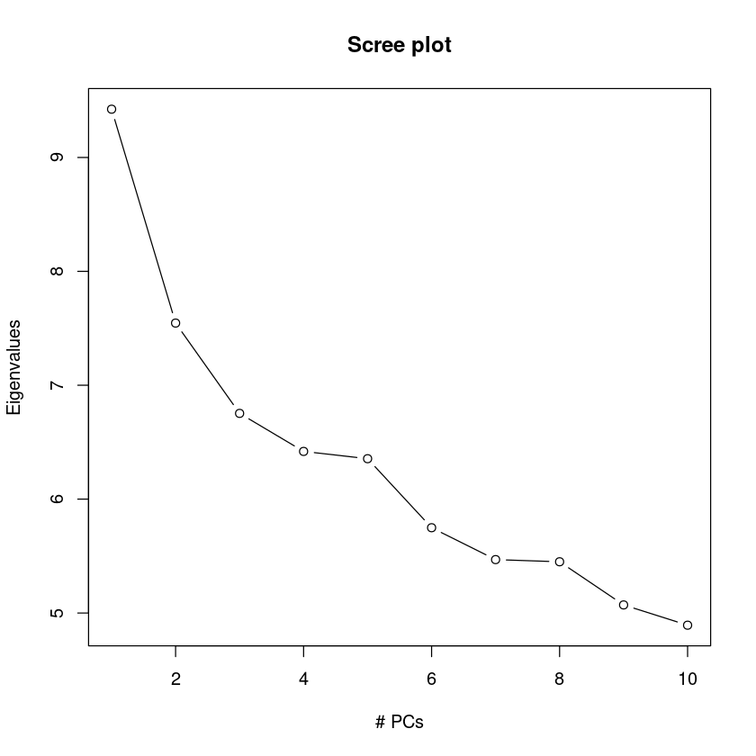

```python
# R codes- run in R Console
# generate plot in R
pc_eig <- read.table("./Data/PC/pc_eig.txt",header=F) # read in eigenvalue
names(pc_eig) <- "eig"

# generate scree plot-- eigenvalue vs # of PC
plot(1:10, pc_eig$eig, type="b", xlab="# PCs", ylab="Eigenvalues",
main="Scree plot")
```

Usually, we use a cut-off of eigenvalue > 1. In this plot, this criteria results in an unreasonable high number of factors, because the eigenvalue for PC 10 is still > 1.

## Test the Significance of Principle Components (PCs)

The following command creates a matrix from **genotype_1k.pca** (in Linux)

```python
# bash codes- run in terminal
# Windows user need to run in Powershell App
tail -n+12 ./Data/PC/genotype_1k.pca > ./Data/PC/pc.txt
```

The following commands employ linear regression to the test the significance of PCs. P values can be found in the last column of the table: `Pr(>|t|)`.

- phenotype file: r_met.txt

```python
# R codes- run in R Console
y=read.table("./Data/PC/r_met.txt") #read phenotype data
pc=read.table("./Data/PC/pc.txt") #read pc data
y=as.matrix(y) #create a matrix from phenotype data
pc=as.matrix(pc) #create a matrix from pc data
fit=lm(y~pc)
summary(fit)
```

```
Call:
lm(formula = y ~ pc)

Residuals:
     Min       1Q   Median       3Q      Max
-2.93261 -0.56311 -0.00616  0.63983  2.73666

Coefficients:
              Estimate Std. Error t value Pr(>|t|)
(Intercept)  9.869e-06  5.404e-02   0.000   0.9999
pcV1         3.034e-01  1.002e+00   0.303   0.7623
pcV2        -8.976e-01  1.002e+00  -0.895   0.3712
pcV3        -8.568e-02  1.002e+00  -0.085   0.9319
pcV4        -7.145e-01  1.002e+00  -0.713   0.4765
pcV5        -1.805e+00  1.002e+00  -1.801   0.0727 .
pcV6         6.453e-01  1.002e+00   0.644   0.5202
pcV7        -1.112e+00  1.002e+00  -1.109   0.2681
pcV8        -4.998e-01  1.002e+00  -0.499   0.6184
pcV9         5.221e-01  1.002e+00   0.521   0.6028
pcV10       -8.423e-01  1.002e+00  -0.840   0.4013
---
Signif. codes:  0 ‘***’ 0.001 ‘**’ 0.01 ‘*’ 0.05 ‘.’ 0.1 ‘ ’ 1

Residual standard error: 1.002 on 333 degrees of freedom
Multiple R-squared:  0.02209,	Adjusted R-squared:  -0.007276
F-statistic: 0.7522 on 10 and 333 DF,  p-value: 0.6749
```

# Simple Association Test

PLINK is a free, open-source whole genome association analysis toolset, designed to perform a range of basic, large-scale analyses in a computationally efficient manner, see http://zzz.bwh.harvard.edu/plink/.

The input files include PED file, MAP file, alternate phenotype file, and optional covariate file.

The PED file is a white-space (space or tab) delimited file, the first six columns are mandatory:

```
Col 1: Family ID

Col 2: Individual ID

Col 3: Paternal ID

Col 4: Maternal ID

Col 5: Sex (1=male; 2=female; other character =unknown)

Col 6: Phenotype (The missing phenotype value for quantitative traits is, by default, -9)

Col 7(*): Genotype (The missing genotype value is denoted as 0, by default)
```

Example:

```
FAM001 1 0 0 1 3.4 A A G G A C C C

FAM001 2 0 0 1 2.5 A A A G 0 0 A C
```

The MAP file has four columns:

```
Col 1: Chromosome (1-22, X, Y or 0 if unplaced)

Col 2: rs# or SNP identifier

Col 3: Genetic distance (morgans)

Col 4: Base-pair position (bp units)
```

To specify an alternate phenotype for analysis, i.e. other than the one in the .ped file, use the option --pheno. The alternate phenotype file has three columns:

```
 Col 1: Family ID

 Col 2: Individual ID

 Col 3: Phenotype
```

Example:

```
 F1     1110     2.30   22.22  2

 F2     2202     34.12  18.23  1
```

The phenotype can be either a quantitative trait or an affection status column. PLINK will automatically detect which type it is based on whether a value other than 0, 1, 2 or the missing genotype code is observed.

## Quantitative Trait Association Test for Continuous Trait

Below is an example that demonstrates how to use PLINK to perform a quantitative trait association test for a toy dataset with a continuous trait and 5 SNPs:

- Genotype data:
  - 5SNPs.ped
  - 5SNPs.map
- Phenotype data:
  - conty.txt

The following commands perform the **simple association test**

1. **--assoc**, perform case/control or QTL association. You can also use **--fisher** to do Fisher's exact (allelic) test or **--model** to do Cochran-Armitage and full-model C/C association.
2. **--pheno**, specify the phenotype file.

```python
# both Mac and Windows can run in Terminal

# macOS user
./Tools/PLINK/plink_mac_20230116/plink \
--noweb --file ./Data/Assoc/5SNPs --assoc --pheno ./Data/Assoc/conty.txt --out ./Data/Assoc/younameit.conty

# Windows user
./Tools/PLINK/plink_win64_20230116/plink.exe \
--noweb --file ./Data/Assoc/5SNPs --assoc --pheno ./Data/Assoc/conty.txt --out ./Data/Assoc/younameit.conty
```

```
PLINK v1.90b6.21 64-bit (19 Oct 2020)          www.cog-genomics.org/plink/1.9/
(C) 2005-2020 Shaun Purcell, Christopher Chang   GNU General Public License v3
Logging to ./Data/Assoc/younameit.conty.log.
Options in effect:
  --assoc
  --file ./Data/Assoc/5SNPs
  --noweb
  --out ./Data/Assoc/younameit.conty
  --pheno ./Data/Assoc/conty.txt

Note: --noweb has no effect since no web check is implemented yet.
257520 MB RAM detected; reserving 128760 MB for main workspace.
.ped scan complete (for binary autoconversion).313141414151515151616161717171718181819191919202020212121212…%
Performing single-pass .bed write (5 variants, 344 people).
--file: ./Data/Assoc/younameit.conty-temporary.bed +3637383940414243444546474849505152535455565758596061626364656667686970717273747576777879808182838485868788899091929394%
./Data/Assoc/younameit.conty-temporary.bim +
./Data/Assoc/younameit.conty-temporary.fam written.
5 variants loaded from .bim file.
344 people (281 males, 0 females, 63 ambiguous) loaded from .fam.
Ambiguous sex IDs written to ./Data/Assoc/younameit.conty.nosex .
344 phenotype values present after --pheno.
Warning: Ignoring phenotypes of missing-sex samples.  If you don't want those
phenotypes to be ignored, use the --allow-no-sex flag.
Using 1 thread (no multithreaded calculations invoked).
Before main variant filters, 344 founders and 0 nonfounders present.
Calculating allele frequencies... 10111213141516171819202122232425262728293031323334353637383940414243444546474849505152535455565758596061626364656667686970717273747576777879808182838485868788899091929394959697989 done.
Total genotyping rate is 0.976744.
5 variants and 344 people pass filters and QC.
Phenotype data is quantitative.
Writing QT --assoc report to ./Data/Assoc/younameit.conty.qassoc ... done.
```

This will generate the output file **["younameit.conty.qassoc"](https://github.com/danniliustat/bigcare/blob/main/Data/Assoc/younameit.conty.qassoc)** with following columns:

```
CHR      Chromosome number

SNP      SNP identifier

BP       Physical position (base-pair)

NMISS    Number of non-missing genotypes

BETA     Regression coefficient

SE       Standard error

R2       Regression r-squared

T        Wald test (based on t-distribution)

P        Wald test asymptotic p-value
```

```python
# bash codes- run in terminal
# Windows user need to run in Powershell App
head ./Data/Assoc/younameit.conty.qassoc
```

```
 CHR         SNP         BP    NMISS       BETA         SE         R2        T            P
   1   rs3094315     752566      280    0.07487     0.1485  0.0009132   0.5041       0.6146
   1   rs2073813     753541      272    0.07533     0.1007   0.002068   0.7481       0.4551
   1   rs3131969     754182      271     0.1038    0.09773   0.004176    1.062       0.2892
   1   rs3131967     754334      280    0.06321     0.1045   0.001313   0.6046        0.546
   1  rs77598327     757120      275    0.08091     0.1341   0.001332   0.6035       0.5467
```

## Case/Control Asssociation Test for Binary Trait

Below is an example that demonstrates how to use PLINK to perform a case/control association test for a binary trait and 5 SNPs:

- Genotype data:
  - 5SNPs.ped
  - 5SNPs.map
- Phenotype data:
  - biny.txt

The following commands perform the **simple association test**

1. **--assoc**, perform case/control or QTL association. You can also use **--fisher** to do Fisher's exact (allelic) test or **--model** to do Cochran-Armitage and full-model C/C association.
2. **--pheno**, specify the phenotype file.

```python
# both Mac and Windows can run in Terminal

# macOS user
./Tools/PLINK/plink_mac_20230116/plink \
--noweb --file ./Data/Assoc/5SNPs --assoc --pheno ./Data/Assoc/biny.txt --out ./Data/Assoc/younameit.biny

# Windows user
./Tools/PLINK/plink_win64_20230116/plink.exe \
--noweb --file ./Data/Assoc/5SNPs --assoc --pheno ./Data/Assoc/biny.txt --out ./Data/Assoc/younameit.biny
```

```
PLINK v1.90b6.21 64-bit (19 Oct 2020)          www.cog-genomics.org/plink/1.9/
(C) 2005-2020 Shaun Purcell, Christopher Chang   GNU General Public License v3
Logging to ./Data/Assoc/younameit.biny.log.
Options in effect:
  --assoc
  --file ./Data/Assoc/5SNPs
  --noweb
  --out ./Data/Assoc/younameit.biny
  --pheno ./Data/Assoc/biny.txt

Note: --noweb has no effect since no web check is implemented yet.
257520 MB RAM detected; reserving 128760 MB for main workspace.
.ped scan complete (for binary autoconversion).313141414151515151616161717171718181819191919202020212121212…%
Performing single-pass .bed write (5 variants, 344 people).
--file: ./Data/Assoc/younameit.biny-temporary.bed +53637383940414243444546474849505152535455565758596061626364656667686970717273747576777879808182838485868788899091929394%
./Data/Assoc/younameit.biny-temporary.bim +
./Data/Assoc/younameit.biny-temporary.fam written.
5 variants loaded from .bim file.
344 people (281 males, 0 females, 63 ambiguous) loaded from .fam.
Ambiguous sex IDs written to ./Data/Assoc/younameit.biny.nosex .
344 phenotype values present after --pheno.
Warning: Ignoring phenotypes of missing-sex samples.  If you don't want those
phenotypes to be ignored, use the --allow-no-sex flag.
Using 1 thread (no multithreaded calculations invoked).
Before main variant filters, 344 founders and 0 nonfounders present.
Calculating allele frequencies... 10111213141516171819202122232425262728293031323334353637383940414243444546474849505152535455565758596061626364656667686970717273747576777879808182838485868788899091929394959697989 done.
Total genotyping rate is 0.976744.
5 variants and 344 people pass filters and QC.
Among remaining phenotypes, 137 are cases and 144 are controls.  (63 phenotypes
are missing.)
Writing C/C --assoc report to ./Data/Assoc/younameit.biny.assoc ...
done.
```

The output is **["younameit.biny.assoc"](https://github.com/danniliustat/bigcare/blob/main/Data/Assoc/younameit.biny.assoc)**, which contains the fields:

```
 CHR     Chromosome
 SNP     SNP ID
 BP      Physical position (base-pair)
 A1      Minor allele name (based on whole sample)
 F_A     Frequency of this allele in cases
 F_U     Frequency of this allele in controls
 A2      Major allele name
 CHISQ   Basic allelic test chi-square (1df)
 P       Asymptotic p-value for this test
 OR      Estimated odds ratio (for A1, i.e. A2 is reference)
```

```python
# bash codes- run in terminal
# Windows user need to run in Powershell App
head ./Data/Assoc/younameit.biny.assoc
```

```
 CHR         SNP         BP   A1      F_A      F_U   A2        CHISQ            P           OR
   1   rs3094315     752566    G  0.07664  0.09091    A       0.3705       0.5428         0.83
   1   rs2073813     753541    A   0.2239   0.2391    G       0.1777       0.6734       0.9178
   1   rs3131969     754182    A   0.2176   0.2607    G        1.383       0.2396       0.7884
   1   rs3131967     754334    A   0.1949   0.2326    G        1.186       0.2761       0.7983
   1  rs77598327     757120    G   0.1111   0.1393    A       0.9945       0.3186       0.7724
```

## Quantitative Trait Association Test for Continuous Trait with Covariates

Below is an example that demonstrates how to use PLINK to perform a quantitative trait test for a continuous trait and 5 SNPs with 3 covariates:

1. Genotype data:
   - 5SNPs.ped
   - 5SNPs.map
2. Phenotype data:
   - conty_pheno.txt
3. Covariates:
   - conty_covar.txt

Before the association test, we adjust the phenotypes to remove the effects of covariates. For the continous phenotype, we employ linear regression to adjust the phenotype. Then, we use the residual as the new phenotype in the association test.

### Covariates adjustments (using R):

```python
## R codes- run in R Console
# Read phenotype data and covariates data
pheno=read.table("./Data/Assoc/conty_pheno.txt") #read phenotype data
covar=read.table("./Data/Assoc/conty_covar.txt") #read covariates data
pheno=as.matrix(pheno) #create a matrix from the phenotype data
covar=as.matrix(covar) #create a matrix from the covariates data
n=dim(pheno)[1] #sample size
p=dim(pheno)[2] #number of traits
```

Covariates adjustment is done by fitting a linear regression model and obtain residuals as new phenotype data for association test.

The following codes construct the linear model for each of the traits using `lm` function.The resulted residual data is saved for analysis.

```python
# R codes- run in R Console
fit=list() #create an empty list
residpheno=matrix(0, n, p) #create an empty matrix
for (i in 1:p){
  fit[[i]]=lm(pheno[,i]~covar) #for each trait, fit a linear regression model of phenotype against covariates
  residpheno[,i]=resid(fit[[i]]) #obtain residual phenotype data
}
write.table(residpheno, "./Data/Assoc/resid_phenotype.txt", row.names=F, col.names=F, quote=F, sep=" ") #save residual phenotype data
```

### Residual phenotype data after covariates adjustments (in UNIX):

This code combines the above residual data and sample ID information to contruct the phenotype data for PLINK.

```python
# bash codes- run in terminal
# Windows user need to run in Powershell App
paste ./Data/Assoc/famID.txt ./Data/Assoc/sampleID.txt \
./Data/Assoc/resid_phenotype.txt > ./Data/Assoc/resid_phenotype_assoc.txt
```

Then we can use PLINK to perform the association test.

### Association test using plink

After adjusting the phenotype using a set of covariates, we use the residual as new phenotype for the association test. `PLINK` was used again to perform assiciation test.

```python
# both Mac and Windows can run in Terminal

# macOS user
./Tools/PLINK/plink_mac_20230116/plink \
--noweb --file ./Data/Assoc/5SNPs --assoc --pheno ./Data/Assoc/resid_phenotype_assoc.txt \
--out ./Data/Assoc/younameit_resid

# Windows user
./Tools/PLINK/plink_win64_20230116/plink.exe \
--noweb --file ./Data/Assoc/5SNPs --assoc --pheno ./Data/Assoc/resid_phenotype_assoc.txt \
--out ./Data/Assoc/younameit_resid
```

```
PLINK v1.90b6.21 64-bit (19 Oct 2020)          www.cog-genomics.org/plink/1.9/
(C) 2005-2020 Shaun Purcell, Christopher Chang   GNU General Public License v3
Logging to ./Data/Assoc/younameit_resid.log.
Options in effect:
  --assoc
  --file ./Data/Assoc/5SNPs
  --noweb
  --out ./Data/Assoc/younameit_resid
  --pheno ./Data/Assoc/resid_phenotype_assoc.txt

Note: --noweb has no effect since no web check is implemented yet.
257520 MB RAM detected; reserving 128760 MB for main workspace.
.ped scan complete (for binary autoconversion).313141414151515151616161717171718181819191919202020212121212…%
Performing single-pass .bed write (5 variants, 344 people).
--file: ./Data/Assoc/younameit_resid-temporary.bed +3637383940414243444546474849505152535455565758596061626364656667686970717273747576777879808182838485868788899091929394%
./Data/Assoc/younameit_resid-temporary.bim +
./Data/Assoc/younameit_resid-temporary.fam written.
5 variants loaded from .bim file.
344 people (281 males, 0 females, 63 ambiguous) loaded from .fam.
Ambiguous sex IDs written to ./Data/Assoc/younameit_resid.nosex .
344 phenotype values present after --pheno.
Warning: Ignoring phenotypes of missing-sex samples.  If you don't want those
phenotypes to be ignored, use the --allow-no-sex flag.
Using 1 thread (no multithreaded calculations invoked).
Before main variant filters, 344 founders and 0 nonfounders present.
Calculating allele frequencies... 10111213141516171819202122232425262728293031323334353637383940414243444546474849505152535455565758596061626364656667686970717273747576777879808182838485868788899091929394959697989 done.
Total genotyping rate is 0.976744.
5 variants and 344 people pass filters and QC.
Phenotype data is quantitative.
Writing QT --assoc report to ./Data/Assoc/younameit_resid.qassoc ... done.
```

```python
# bash codes- run in terminal
# Windows user need to run in Powershell App
### check association results
head ./Data/Assoc/younameit_resid.qassoc
```

```
 CHR         SNP         BP    NMISS       BETA         SE         R2        T            P
   1   rs3094315     752566      280     0.0706      0.148  0.0008178    0.477       0.6337
   1   rs2073813     753541      272    0.07739     0.1003   0.002198   0.7713       0.4412
   1   rs3131969     754182      271     0.1062     0.0974     0.0044     1.09       0.2766
   1   rs3131967     754334      280    0.06205     0.1042   0.001274   0.5954       0.5521
   1  rs77598327     757120      275     0.0816     0.1336   0.001366    0.611       0.5417
```

This output file **["younameit_resid.qassoc"](https://github.com/danniliustat/bigcare/blob/main/Data/Assoc/younameit_resid.qassoc)** has the following columns:

```
CHR      Chromosome number

SNP      SNP identifier

BP       Physical position (base-pair)

NMISS    Number of non-missing genotypes

BETA     Regression coefficient

SE       Standard error

R2       Regression r-squared

T        Wald test (based on t-distribution)

P        Wald test asymptotic p-value
```

In the next section, we will start analyzing real data from a case study. The procedures might not be exactly the same here, as real data require more proprocessing steps before it can be used for association study.